# Getting started with GitHub

Lucas Nell >  
11 Oct 2017

Presentation available at `lucasnell.com/github_gsis`

### Why use git and GitHub?

[figure not shown]

- Collaborating with a team
- Sharing code with strangers
- Tracing and avoiding horrible mistakes

### git and GitHub overview

[figure not shown]

### Today's goals

1. Tell git who you are
2. Connect securely to GitHub
3. Create a test repository
4. Clone, commit, and push your repository

### Prerequisites

- git
- GitHub account
- R and RStudio

### Telling git who you are

In RStudio, `Tools` > `Shell...`

Set global defaults for name and email. Make sure the email below is the one you use for your GitHub account

```bash
git config --global user.name 'John Doe'
git config --global user.email 'john@doe.com'
```

Output from this command…

```bash
git config --global --list
```

… should include this:

```bash
user.name=John Doe
user.email=john@doe.com
```

### Connecting securely to GitHub using SSH

First, check if you already have an SSH key

From R:

```r
file.exists("~/.ssh/id_rsa.pub")
# Windows:
# file.exists("C:/Users/USERNAME/.ssh/id_rsa")
```

If `FALSE`, you need to make a public key first…

### Making and viewing key

[figure not shown]

from `https://r-pkgs.org/git.html#git-setup`

### Adding key to GitHub

Login to `github.com` in web browser

Go to `https://github.com/settings/ssh`

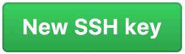

Enter a descriptive title (e.g., “Personal MacBook Pro”)

Paste your key into the “Key” box

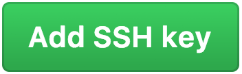

### Initiate new repository

From `github.com`:

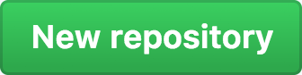

From profile page:

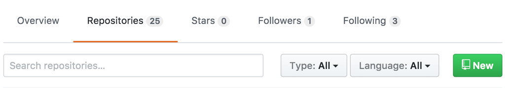

### Describe and create new repository

[figure not shown]

* If not using R, leave at “None” or change to language you're using

### Clone repository in RStudio

`File` > `New Project` > `Version Control` > `Git`

[figure not shown]

### Make local changes

If just using a test repo, edit the `README.md` file and save changes.

If wanting to move a directory over to GitHub, copy those files into the new repository's folder

### Commit and Push

1. Under “Git” tab, checked “Staged” for file(s) that you changed or added
2. Hit “Commit”
3. Add useful commit message
4. Hit “Commit” again
5. Hit “Push”

If the above works, then you're successfully using GitHub through RStudio

### Additional resources

- Source of info for much of this presentation: `happygitwithr.com`
- GitHub Education (for free private repos): `education.github.com`
- Simple command line guide: `rogerdudler.github.io/git-guide`
- Recommended git clients (RStudio isn't great to use long-term)
  - GitKraken: `gitkraken.com`
  - SourceTree: `sourcetreeapp.com`
- This presentation is available at `lucasnell.com/github_gsis`